# Introduction to Mixed-Effects Models

Martin Zettersten

18 February, 2025

This code borrows heavily from the following sources:

- Brown VA. An Introduction to Linear Mixed-Effects Modeling in R. Advances in Methods and Practices in Psychological Science. 2021;4(1). doi:10.1177/2515245920960351
  - Associated OSF page with data and code: https://osf.io/v6qag/
- Winter, B. (2013). Linear models and linear mixed effects models in R with linguistic applications. arXiv. http://arxiv.org/ abs/1308.5499
- For a more in-depth guide, see: Brauer, M., & Curtin, J. (2018). Linear mixed-effects models and the analysis of nonindependent data: A unified framework to analyze categorical and continuous independent variables that vary within-subjects and/or within-items. *Psychological Methods, 23*(3), 389-411. https://doi.org/10.1037/met0000159

# Preliminaries

Install packages if they aren’t already installed (notice the nice compact code here that avoids re-installing the package if it already is found in your R environment).

```r
if (!("knitr" %in% installed.packages())) install.packages("knitr")
if (!("lme4" %in% installed.packages())) install.packages("lme4")
if (!("lmerTest" %in% installed.packages())) install.packages("lmerTest")
if (!("tidyverse" %in% installed.packages())) install.packages("tidyverse")
if (!("broom.mixed" %in% installed.packages())) install.packages("broom.mixed")
if (!("afex" %in% installed.packages())) install.packages("afex")
if (!("papaja" %in% installed.packages())) install.packages("papaja")
if (!("here" %in% installed.packages())) install.packages("here")
if (!("performance" %in% installed.packages())) install.packages("performance")
```

Load libraries and set up paths

```r
library(lme4)
library(lmerTest)
library(tidyverse)
library(broom.mixed)
library(afex)
library(papaja)
library(knitr)
library(here)
library(performance)

data_path <- here("data")
```

# General problem

# Inspect the data

Load data, and name that object “rt_data”

```r
rt_data <- read_csv(here(data_path,"rt_dummy_data.csv"))
```

View the first six rows of the data frame

```r
head(rt_data)
```

```
## # A tibble: 6 × 4
##     PID    RT modality   stim
##   <dbl> <dbl> <chr>      <chr>
## 1   301  1024 Audio-only gown
## 2   301   838 Audio-only might
## 3   301  1060 Audio-only fern
## 4   301   882 Audio-only vane
## 5   301   971 Audio-only pup
## 6   301  1064 Audio-only rise
```

# Fit a linear mixed-effects model

```r
rt_mod <- lmer(RT ~ 1 + modality +
                      (1 + modality|PID),
                    data = rt_data)
```

Inspect the summary output.

```r
summary(rt_mod)
```

```
## Linear mixed model fit by REML. t-tests use Satterthwaite's method [
## lmerModLmerTest]
## Formula: RT ~ 1 + modality + (1 + modality | PID)
##    Data: rt_data
##
## REML criterion at convergence: 302400.8
##
## Scaled residuals:
##     Min      1Q  Median      3Q     Max
## -3.3640 -0.6991 -0.0141  0.5903  5.0118
##
## Random effects:
##  Groups   Name                Variance Std.Dev. Corr
##  PID      (Intercept)         28541    168.9
##           modalityAudiovisual  7709     87.8    -0.17
##  Residual                     65715    256.3
## Number of obs: 21679, groups:  PID, 53
##
## Fixed effects:
##                     Estimate Std. Error      df t value Pr(>|t|)
## (Intercept)          1044.08      23.34   52.04  44.733  < 2e-16 ***
## modalityAudiovisual    83.11      12.56   51.87   6.617 2.04e-08 ***
## ---
## Signif. codes:  0 '***' 0.001 '**' 0.01 '*' 0.05 '.' 0.1 ' ' 1
##
## Correlation of Fixed Effects:
##             (Intr)
## modltyAdvsl -0.179
```

Let’s try to make sense of some of the key pieces.

Focus first on the fixed effects model summary. This looks a lot like the output we get from a linear regression model.

## Generate pretty output

There’s a growing number of excellent options for quickly printing lovely APA-style model outputs and regression tables

### Option 1: `tidy()` from `broom.mixed`

First, let’s use some nice R functions for getting cleaner output of the model. For this, we can use the nifty `broom` package.

```r
rt_mod %>%
  tidy() %>%
  filter(effect=="fixed") %>%
  select(-group,-effect) %>%
  kable(digits=8)
```

| term | estimate | std.error | statistic | df | p.value |
| --- | --- | --- | --- | --- | --- |
| (Intercept) | 1044.0786 | 23.34039 | 44.732692 | 52.04062 | 0e+00 |
| modalityAudiovisual | 83.1101 | 12.56097 | 6.616533 | 51.86638 | 2e-08 |

### Option 2: `apa_print()` from `papaja`

First, use the `apa_print()` method from `papaja` to get a structured object representing the model outputs in APA-friendly format

```r
lmer_output <- apa_print(rt_mod)
```

This object now contains summaries of the model output formatted in a way that they directly print out in APA format in an R markdown document. For example, we found a significant effect of modality on reaction time, $\hat{\beta} = 83.11$, 95% CI $[58.49, 107.73]$, $t(51.87) = 6.62$, $p < .001$.

We can also output a (basically) publication-ready regression table.

```r
lmer_output %>%
  #optionally: give columns desired names
  label_variables(
  Term = "Model Coefficient"
  ) %>%
  apa_table(
    caption = "Estimates for linear mixed-effects model predicting",
    note = "Degrees of freedom estimated using the Satterthwaite approximation.",
    results="asis")
```

(#tab:unnamed-chunk-9) Estimates for linear mixed-effects model predicting

| Term | $\hat{\beta}$ | 95% CI | $t$ | $\mathit{df}$ | $p$ |
| --- | --- | --- | --- | --- | --- |
| Intercept | 1,044.08 | [998.33, 1,089.82] | 44.73 | 52.04 | < .001 |
| ModalityAudiovisual | 83.11 | [58.49, 107.73] | 6.62 | 51.87 | < .001 |

*Note.* Degrees of freedom estimated using the Satterthwaite approximation.

## Interpret the output

### Fixed Effects

The fixed effects can be interpreted very similarly to a typical linear regression model. Intercepts reflect the model estimate when all other predictors are set to zero. Estimates for simple predictors are slopes, reflecting how the DV is estimated to increase for a unit-change in the predictor (if there are interactions, this is the slope at when all other predictors are set to zero). Interactions reflect how the slope associated with a given predictor changes as a function of another variable.

Note that in addition to the summary command, R also gives us a function to extract the fixed effects directly.

```r
fixef(rt_mod)
```

```
##         (Intercept) modalityAudiovisual
##           1044.0786             83.1101
```

### Estimating p-values for fixed effects

#### Approximating df

We are using `lmerTest()` to estimate the p-values for the fixed effects. The underlying problem for estimating p-values is that it’s not clear what degrees of freedom make sense for a mixed-effects model The `lmerTest` uses a particular method to estimate the p-values, called the Satterthwaite approximation. Another possible method for estimating df’s (probably more robust) is the Kenward-Roger approximation, which is implemented in the `pbkrtest` package.

#### Null model approach (w/ likelihood ratio test)

Another common way that people often use to estimate p-values in mixed-effects models is to compare the full model to a null model that includes all of the same parameters *except* the key parameter of interest (in this instance, modality condition).

Full model: $RT ~ 1 + modality + (1 + modality|PID)$ Null model: $RT ~ 1 + (1 + modality|PID)$

```r
# fit the null model
rt_mod_null <- lmer(RT ~ 1 +
                      (1 + modality|PID),
                    data = rt_data)
```

Now, we use the `anova()` command to compare the full model to the null model using a likelihood ratio test.

```r
anova(rt_mod_null,rt_mod)
```

```
## refitting model(s) with ML (instead of REML)
```

```
## Data: rt_data
## Models:
## rt_mod_null: RT ~ 1 + (1 + modality | PID)
## rt_mod: RT ~ 1 + modality + (1 + modality | PID)
##             npar    AIC    BIC  logLik deviance  Chisq Df Pr(>Chisq)
## rt_mod_null    5 302458 302498 -151224   302448
## rt_mod         6 302428 302476 -151208   302416 32.375  1  1.271e-08 ***
## ---
## Signif. codes:  0 '***' 0.001 '**' 0.01 '*' 0.05 '.' 0.1 ' ' 1
```

Let’s inspect this a bit and see if we can make sense of the main bits of input.

Just for fun and to demystify a bit, here’s where the chisquared statistic and the p-value are coming from.

```r
#compute chi-squared value
chi_sq <- 2 * (logLik(rt_mod, REML=FALSE) - logLik(rt_mod_null, REML=FALSE))
chi_sq
```

```
## 'log Lik.' 32.36581 (df=6)
```

```r
#get p-value (why df=1?)
pchisq(chi_sq, df=1, lower.tail=FALSE)
```

```
## 'log Lik.' 1.277137e-08 (df=6)
```

Note that the `summary()` command also outputs the results of a comparison of the full model to a null model “under the hood”. This approach just makes that process more explicit, and then conducts a slightly different test for estimating the p-value (the likelihood ratio test).

Compare this outcome to the p-value estimated using the Satterthwaite approximation. How similar are the results?

### Example description

To investigate the effect of modality on reaction time, we fit a linear mixed-effects model predicting reaction time from modality condition (dummy coded). We included a by-participant random intercept and by-participant random slope for modality. Degrees of freedom were estimated using the Satterthwaite approximation. Reaction times were higher in the audio-visual condition than in the audio-only condition, $\hat{\beta} = 83.11$, 95% CI $[58.49, 107.73]$, $t(51.87) = 6.62$, $p < .001$.

### Recoding variables to make output more interpretable

A good general heuristic to keep in mind:

Always center your predictors and code them such that a unit change is meaningfully interpretable.

```r
rt_data <- rt_data %>%
  mutate(
    modality_c = ifelse(modality=="Audio-only",-0.5,0.5)
  )
```

Let’s now refit the model with modality centered.

```r
rt_mod_c <- lmer(RT ~ 1 + modality_c +
                      (1 + modality_c|PID),
                    data = rt_data)
summary(rt_mod_c)
```

```
## Linear mixed model fit by REML. t-tests use Satterthwaite's method [
## lmerModLmerTest]
## Formula: RT ~ 1 + modality_c + (1 + modality_c | PID)
##    Data: rt_data
##
## REML criterion at convergence: 302400.8
##
## Scaled residuals:
##     Min      1Q  Median      3Q     Max
## -3.3640 -0.6991 -0.0141  0.5903  5.0118
##
## Random effects:
##  Groups   Name        Variance Std.Dev. Corr
##  PID      (Intercept) 28011    167.4
##           modality_c   7709     87.8    0.10
##  Residual             65715    256.3
## Number of obs: 21679, groups:  PID, 53
##
## Fixed effects:
##             Estimate Std. Error      df t value Pr(>|t|)
## (Intercept)  1085.63      23.06   52.02  47.086  < 2e-16 ***
## modality_c     83.11      12.56   51.87   6.617 2.04e-08 ***
## ---
## Signif. codes:  0 '***' 0.001 '**' 0.01 '*' 0.05 '.' 0.1 ' ' 1
##
## Correlation of Fixed Effects:
##            (Intr)
## modality_c 0.091
```

What’s changed compared to the model in which modality is not centered? (hint: check out and compare the estimates between the two models)

Some advantages of centering include:

- improves interpretability
- avoids worst risks of misinterpretation when fitting interaction models - improves likelihood that linear mixed-effects models will converge (helps reduce covariance between random effects parameters)
- depending on centering strategy (within- vs. between-participants), can ensure that fixed effects are clearly interpretable as within-participant effects (see also Simpson’s paradox).

## Random Effects

Let’s dig deeper into the model to understand what exactly the random effects are doing. The random effects capture how much the effects vary at different levels of my random units. In other words, in this case, the random effects capture estimates at the level of individual participants. We’re going to use the `lattice` package to easily visualize this.

First, R provides a few convenience functions for extracting the random effects. The first we’ll look at is `coef()`.

```r
coef(rt_mod_c)
```

```
## $PID
##     (Intercept) modality_c
## 301   1014.9281 -17.496713
## 302   1045.0073   2.114826
## 303    911.5878  57.287348
## 304   1218.2332 -28.509618
## 306   1058.6560  34.062403
## 307   1106.7267  -9.605466
## 308   1286.1686  70.907708
## 309    803.0457  15.743397
## 310   1227.8618 105.017866
## 311   1028.2030  29.849015
## 312   1186.3287 153.333674
## 313   1129.2856  29.580897
## 314   1132.6228 -73.237623
```

[output cut: 43 more lines]

`ranef` is similar, but it instead shows the variation for each participant around the fixed effect.

```r
ranef(rt_mod_c)
```

```
## $PID
##     (Intercept)   modality_c
## 301  -70.705558 -100.6068077
## 302  -40.626406  -80.9952694
## 303 -174.045842  -25.8227473
## 304  132.599521 -111.6197133
## 306  -26.977673  -49.0476923
## 307   21.093056  -92.7155607
## 308  200.534964  -12.2023871
## 309 -282.587971  -67.3666977
## 310  142.228120   21.9077713
## 311  -57.430632  -53.2610800
## 312  100.695031   70.2235789
## 313   43.651897  -53.5291984
## 314   46.989174 -156.3477182
```

[output cut: 42 more lines]

### Visualizing random effects

Now, we can visualize the variation in random effects using `lattice`’s `dotplot`.

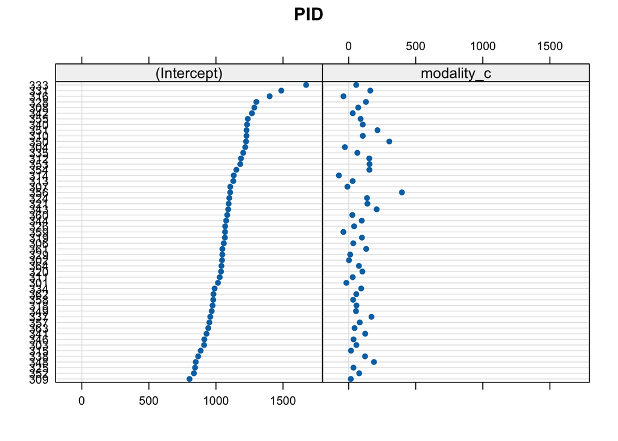

```r
lattice::dotplot(coef(rt_mod_c))
```

For each row in the plot, we see:

- the intercept estimate for each participant, i.e., their estimated average reaction time (note that this interpretation hinges on our centering strategy! What would be the interpretation of the random intercepts for our initial `rt_mod` model?)
- the slope estimate for each participant, i.e. how much their reaction time increases on average between the audio-only condition and audio-visual condition.

What values should the intercepts/slopes (approximately) be centered around?

```r
#check
mean(coef(rt_mod_c)$PID$modality_c)
```

```
## [1] 83.1101
```

```r
mean(coef(rt_mod_c)$PID$`(Intercept)`)
```

```
## [1] 1085.634
```

We can also use `ranef` and `dotplot` to focus on variability around the fixed effects. Notice how the effects are now centered around zero.

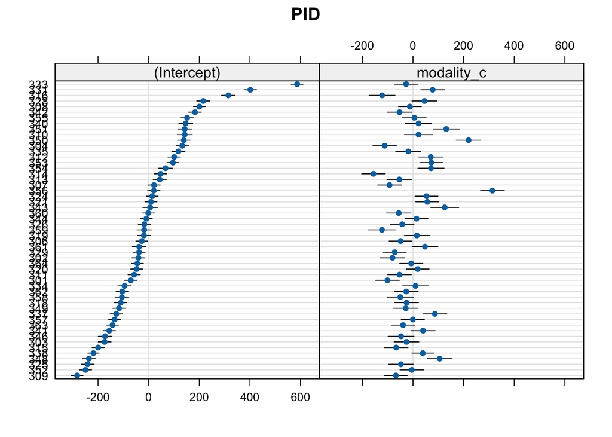

```r
lattice::dotplot(ranef(rt_mod_c))
```

### Visualizing participant-level variation

Let’s visualize the effect for each participant. Can you try to map onto this figure what the random intercept and the random slope for modality represent?

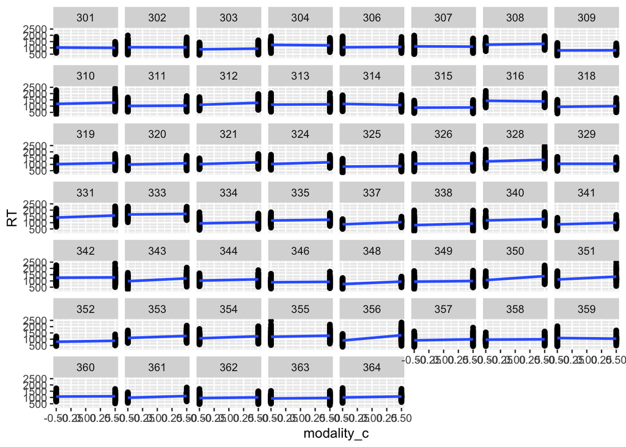

```r
ggplot(rt_data,aes(modality_c,RT))+
  geom_point()+
  geom_smooth(method="lm",se=F)+
  facet_wrap(~PID)
```

# Multiple random effects

If you take a close look at the data, you might notice that there is another potential source of non-independence: the particular words (in the `stim` column). We have multiple observations for each word in our dataset. (Incidentally, this is a problem that has long been recognized in psycholinguistics. One of the first to point this out was Herb Clark in the ’70s. See Clark, H. (1973). “The Language-as-Fixed-Effect Fallacy: A Critique of Language Statistics in Psychological Research”, *Journal of Verbal Learning and Verbal Behavior, 12*, 335-359.) Ideally, we’d like to have a way to simultaneously account not only for non-independence due to participants *AND* non-independence due to words.

```r
rt_data %>%
  arrange(stim) %>%
  head()
```

```
## # A tibble: 6 × 5
##     PID    RT modality   stim  modality_c
##   <dbl> <dbl> <chr>      <chr>      <dbl>
## 1   302   729 Audio-only babe        -0.5
## 2   304  1426 Audio-only babe        -0.5
## 3   306  1320 Audio-only babe        -0.5
## 4   308  1279 Audio-only babe        -0.5
## 5   310  1008 Audio-only babe        -0.5
## 6   312  1531 Audio-only babe        -0.5
```

The elegance of linear mixed-effects regression is that we can easily extend our model to include as many additional random effects units as we need in order to accurately capture the clustered nature of our design. Note that we can have random effects for basically any factor! Participants and stimuli, but also schools, countries, dataset sources (think of ManyLabs/ ManyBabies studies), …. Here’s how we can include random effects due to item.

```r
rt_mod_c_full <- lmer(RT ~ 1 + modality_c +
                      (1 + modality_c|PID) + (1 + modality_c|stim),
                    data = rt_data)
summary(rt_mod_c_full)
```

```
## Linear mixed model fit by REML. t-tests use Satterthwaite's method [
## lmerModLmerTest]
## Formula: RT ~ 1 + modality_c + (1 + modality_c | PID) + (1 + modality_c |
##     stim)
##    Data: rt_data
##
## REML criterion at convergence: 302385.7
##
## Scaled residuals:
##     Min      1Q  Median      3Q     Max
## -3.3646 -0.6964 -0.0140  0.5886  5.0003
##
## Random effects:
##  Groups   Name        Variance Std.Dev. Corr
##  stim     (Intercept)   398.2   19.95
##           modality_c    216.6   14.72   0.51
##  PID      (Intercept) 28030.6  167.42
##           modality_c   7710.5   87.81   0.10
##  Residual             65258.8  255.46
## Number of obs: 21679, groups:  stim, 543; PID, 53
##
## Fixed effects:
##             Estimate Std. Error      df t value Pr(>|t|)
## (Intercept)  1085.73      23.08   52.16  47.042  < 2e-16 ***
## modality_c     83.18      12.58   52.09   6.614 2.02e-08 ***
## ---
## Signif. codes:  0 '***' 0.001 '**' 0.01 '*' 0.05 '.' 0.1 ' ' 1
##
## Correlation of Fixed Effects:
##            (Intr)
## modality_c 0.092
```

Compare the output between this model and previous models. What’s changed?

Notice that we included both a random intercept for stimuli and a random slope for condition. Do you have an intuition about why we might have made this choice? (more below)

Note that we can extend this logic to include **as many types of random effects as we need to capture the structure of our data**! The only limiting factor is whether we have enough data to capture the complexity of our model structure (see more below for dealing with convergence issues and pruning random effects).

# Choosing random effects structure: keep it maximal

A general rule of thumb (Barr et al., 2013) is to keep the random effects structure “maximal”, that is, to include the full random effects structure that is justified by the design of your experiment/ what you know about the data generating process. Otherwise, you are likely going to severely inflate Type I error (see e.g. this blog post for a helpful simulation: https://benediktehinger.de/blog/science/lmm-type-1-error-for-1condition1subject/.

How do you determine the maximal random effects structure? As a general rule, you can apply the following principles:

1. If there are multiple observations for a given unit (e.g., multiple observations per participant), you need a by-unit random intercept.
2. If there are multiple observations for a given predictor (e.g. condition) within unit, you need a by-unit random slope for that predictor (e.g., if condition varies within participant, include a by-participant random slope for condition. If condition varies between participant, do not include a by-participant random slope for condition).
3. Include by unit random slopes for interactions in which all participating predictors vary within-unit (e.g., for an interaction between two predictors that vary within participant, include a by-participant random slope for their interaction).

See also Table 11 in Brauer & Curtin (2018).

# Investigating model performance

It’s good practice to check the extent to which model assumptions for our mixed-effects model are fulfilled. The `performance` package provides a bunch of nice convenience tools for assessing the most important model assumptions. Many of the key assumptions are similar to a linear regression model, namely - linearity of residuals - variance is constant - normality of residuals The main difference is that we can now inspect assumptions at multiple levels of the model (also for random effects).

It’s also useful to get a diagnosis of influential observations (observations that, when removed, lead to large changes in the estimates).

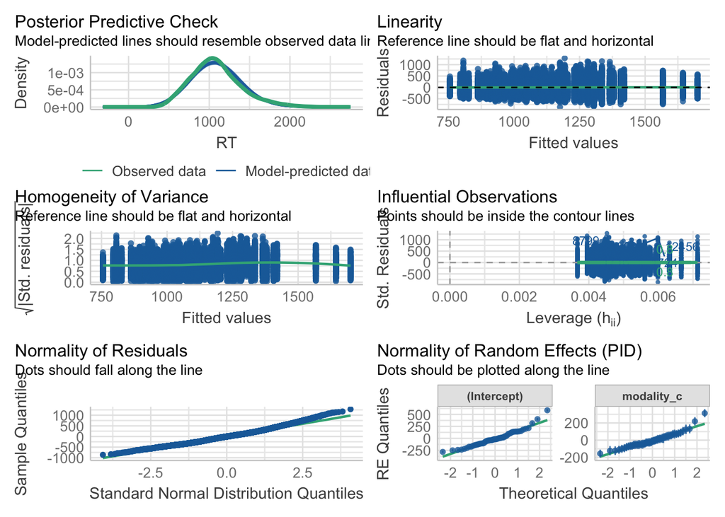

```r
performance::check_model(rt_mod_c,detrend=FALSE)
```

Check out details in the function documentation

```r
?performance::check_model
```

Why do you think the residuals might be non-normal? What might we do to try to address it?

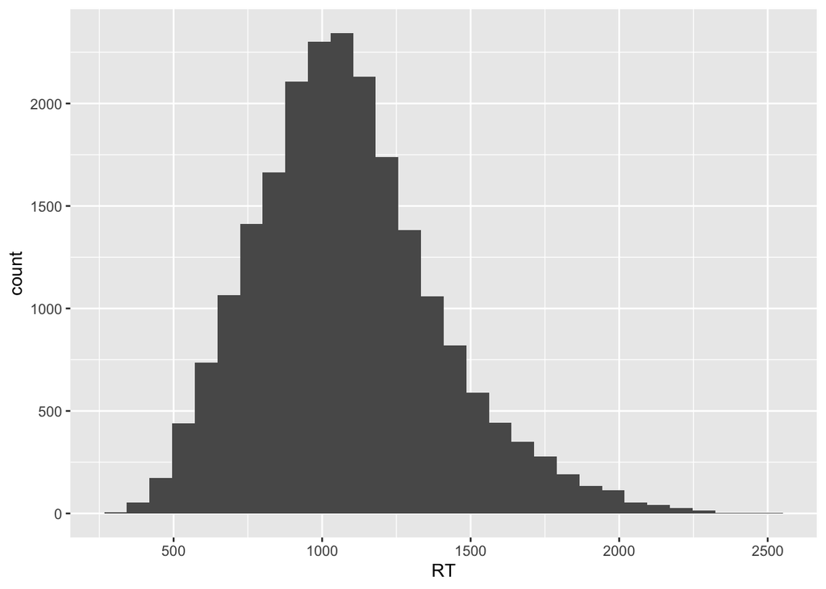

```r
#RT data is skewed
rt_data %>%
  ggplot(aes(RT))+
  geom_histogram()
```

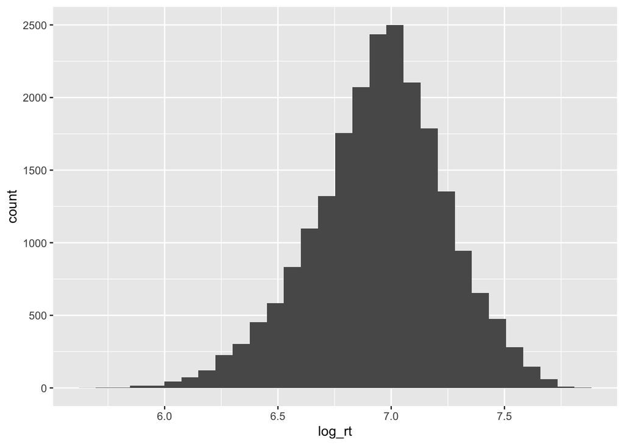

```r
#try log-transforming RT data
rt_data <- rt_data %>%
   mutate(
     log_rt = log(RT)
   )

#replot
rt_data %>%
  ggplot(aes(log_rt))+
  geom_histogram()
```

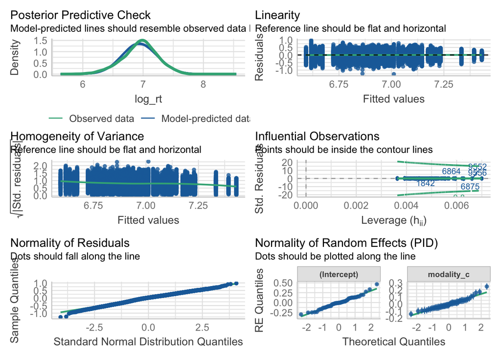

```r
rt_mod_log_c <- lmer(log_rt ~ 1 + modality_c +
                      (1 + modality_c|PID),
                    data = rt_data)
check_model(rt_mod_log_c,detrend=FALSE)
```

```r
#now a little better - still some non-normality in the left tail of the residuals
```

# Interactions

```r
rt_data_interaction <- read_csv(here(data_path,"rt_dummy_data_interaction.csv"))
head(rt_data_interaction)
```

```
## # A tibble: 6 × 5
##     PID    RT SNR   modality   stim
##   <dbl> <dbl> <chr> <chr>      <chr>
## 1   301  1024 Easy  Audio-only gown
## 2   301   838 Easy  Audio-only might
## 3   301  1060 Easy  Audio-only fern
## 4   301   882 Easy  Audio-only vane
## 5   301   971 Easy  Audio-only pup
## 6   301  1064 Easy  Audio-only rise
```

Note that the data now contains an extra parameter, SNR (signal-to-noise ratio), at two levels, easy and hard.

## Fit a model with levels dummy coded

First, let’s fit a naive interaction model. For ease of discussion, I’m going to stick with just the by-participant random effects, but in principle, we want to include the random effects for stim too. [if there’s time: discuss the misspecification of the random effects structure in the Brown introduction, and the consequences for significance.]

```r
rt_int <- lmer(RT ~ 1 + modality * SNR +
                      (1 + modality * SNR|PID),
                    data = rt_data_interaction)
summary(rt_int)
```

```
## Linear mixed model fit by REML. t-tests use Satterthwaite's method [
## lmerModLmerTest]
## Formula: RT ~ 1 + modality * SNR + (1 + modality * SNR | PID)
##    Data: rt_data_interaction
##
## REML criterion at convergence: 300397.7
##
## Scaled residuals:
##     Min      1Q  Median      3Q     Max
## -4.1276 -0.7052  0.0078  0.6062  4.9068
##
## Random effects:
##  Groups   Name                        Variance Std.Dev. Corr
##  PID      (Intercept)                 25252    158.9
##           modalityAudiovisual         18800    137.1    -0.13
##           SNRHard                     17519    132.4    -0.06  0.26
##           modalityAudiovisual:SNRHard 42633    206.5     0.15 -0.76 -0.65
##  Residual                             59120    243.1
## Number of obs: 21679, groups:  PID, 53
##
## Fixed effects:
##                             Estimate Std. Error     df t value Pr(>|t|)
## (Intercept)                   998.39      22.08  51.97  45.226  < 2e-16 ***
## modalityAudiovisual            98.79      19.40  52.10   5.093 4.94e-06 ***
## SNRHard                        91.60      18.79  51.56   4.874 1.09e-05 ***
## modalityAudiovisual:SNRHard   -27.44      29.14  51.77  -0.942    0.351
## ---
## Signif. codes:  0 '***' 0.001 '**' 0.01 '*' 0.05 '.' 0.1 ' ' 1
##
## Correlation of Fixed Effects:
##             (Intr) mdltyA SNRHrd
## modltyAdvsl -0.152
## SNRHard     -0.082  0.278
## mdltyA:SNRH  0.161 -0.753 -0.653
```

Note that by default, R will dummy code categorical variables alphabetically, so the alphabetically first name will be the reference level (coded as 0) and the second level will be coded as 1.

What is the consequence of this coding approach for the interpretation of the interaction term? What is the consequence for the interpretation of the main effects?

## Fit a model with levels flipped

Let’s reverse the dummy coding, so now the other level serves as the reference level.

```r
rt_data_interaction$modality_rev <- ifelse(rt_data_interaction$modality == "Audiovisual", 0, 1)
rt_data_interaction$SNR_rev <- ifelse(rt_data_interaction$SNR == "Hard", 0, 1)
```

Fit the model

```r
rt_int_rev <- lmer(RT ~ 1 + modality_rev * SNR_rev +
                      (1 + modality_rev * SNR_rev|PID),
                    data = rt_data_interaction)
summary(rt_int_rev)
```

```
## Linear mixed model fit by REML. t-tests use Satterthwaite's method [
## lmerModLmerTest]
## Formula: RT ~ 1 + modality_rev * SNR_rev + (1 + modality_rev * SNR_rev |
##     PID)
##    Data: rt_data_interaction
##
## REML criterion at convergence: 300397.7
##
## Scaled residuals:
##     Min      1Q  Median      3Q     Max
## -4.1276 -0.7052  0.0078  0.6062  4.9067
##
## Random effects:
##  Groups   Name                 Variance Std.Dev. Corr
##  PID      (Intercept)          37067    192.5
##           modality_rev         18598    136.4    -0.29
##           SNR_rev              24640    157.0    -0.39  0.39
##           modality_rev:SNR_rev 42626    206.5     0.21 -0.75 -0.77
##  Residual                      59120    243.1
## Number of obs: 21679, groups:  PID, 53
##
## Fixed effects:
##                      Estimate Std. Error      df t value Pr(>|t|)
## (Intercept)           1161.34      26.66   51.99  43.564  < 2e-16 ***
## modality_rev           -71.35      19.34   51.54  -3.689 0.000542 ***
## SNR_rev                -64.16      22.06   52.00  -2.908 0.005338 **
## modality_rev:SNR_rev   -27.44      29.14   51.78  -0.942 0.350694
## ---
## Signif. codes:  0 '***' 0.001 '**' 0.01 '*' 0.05 '.' 0.1 ' ' 1
##
## Correlation of Fixed Effects:
##             (Intr) mdlty_ SNR_rv
## modality_rv -0.303
## SNR_rev     -0.394  0.391
## mdlty_:SNR_  0.218 -0.751 -0.764
```

What changes? What doesn’t change?

## Fit the model with levels centered (right way!!)

Now, let’s fit the model with centered predictors. **This is the way you should typically fit an interaction model.** This is because once the predictor variables are centered, we can now safely interpret the lower-order effects as “main” effects, i.e. as the effect averaging across the other predictor.

```r
rt_data_interaction$modality_c <- ifelse(rt_data_interaction$modality == "Audiovisual", 0.5, -0.5)
rt_data_interaction$SNR_c <- ifelse(rt_data_interaction$SNR == "Hard", 0.5, -0.5)
```

Fit the model

```r
rt_int_c <- lmer(RT ~ 1 + modality_c * SNR_c +
                      (1 + modality_c * SNR_c|PID),
                    data = rt_data_interaction)
summary(rt_int_c)
```

```
## Linear mixed model fit by REML. t-tests use Satterthwaite's method [
## lmerModLmerTest]
## Formula: RT ~ 1 + modality_c * SNR_c + (1 + modality_c * SNR_c | PID)
##    Data: rt_data_interaction
##
## REML criterion at convergence: 300397.7
##
## Scaled residuals:
##     Min      1Q  Median      3Q     Max
## -4.1276 -0.7052  0.0078  0.6062  4.9067
##
## Random effects:
##  Groups   Name             Variance Std.Dev. Corr
##  PID      (Intercept)      27955    167.20
##           modality_c        8042     89.68    0.10
##           SNR_c            10420    102.08    0.20 -0.45
##           modality_c:SNR_c 42625    206.46   -0.12 -0.01  0.17
##  Residual                  59120    243.15
## Number of obs: 21679, groups:  PID, 53
##
## Fixed effects:
##                  Estimate Std. Error      df t value Pr(>|t|)
## (Intercept)       1086.72      23.03   52.02  47.193  < 2e-16 ***
## modality_c          85.07      12.76   51.91   6.666 1.70e-08 ***
## SNR_c               77.88      14.41   51.98   5.403 1.66e-06 ***
## modality_c:SNR_c   -27.44      29.13   51.78  -0.942    0.351
## ---
## Signif. codes:  0 '***' 0.001 '**' 0.01 '*' 0.05 '.' 0.1 ' ' 1
##
## Correlation of Fixed Effects:
##             (Intr) mdlty_ SNR_c
## modality_c   0.100
## SNR_c        0.198 -0.424
## mdlty_:SNR_ -0.113 -0.003  0.159
```

Compare the modality effect to the effects in the centered model including only modality. What do you notice?

```r
summary(rt_mod_c)
```

```
## Linear mixed model fit by REML. t-tests use Satterthwaite's method [
## lmerModLmerTest]
## Formula: RT ~ 1 + modality_c + (1 + modality_c | PID)
##    Data: rt_data
##
## REML criterion at convergence: 302400.8
##
## Scaled residuals:
##     Min      1Q  Median      3Q     Max
## -3.3640 -0.6991 -0.0141  0.5903  5.0118
##
## Random effects:
##  Groups   Name        Variance Std.Dev. Corr
##  PID      (Intercept) 28011    167.4
##           modality_c   7709     87.8    0.10
##  Residual             65715    256.3
## Number of obs: 21679, groups:  PID, 53
##
## Fixed effects:
##             Estimate Std. Error      df t value Pr(>|t|)
## (Intercept)  1085.63      23.06   52.02  47.086  < 2e-16 ***
## modality_c     83.11      12.56   51.87   6.617 2.04e-08 ***
## ---
## Signif. codes:  0 '***' 0.001 '**' 0.01 '*' 0.05 '.' 0.1 ' ' 1
##
## Correlation of Fixed Effects:
##            (Intr)
## modality_c 0.091
```

# More advanced topics

## Dealing with convergence issues

### Testing out alternative optimizers

```r
# allFit() tries out all possible optimizers
# This can take a while to fit, depending on the complexity of the model
#all_fit <- lme4::allFit(rt_mod)
#all_fit
```

### General remedies

See Table 17 in Brauer & Curtin (2018) for a step-by-step approach to dealing with convergence issues.

### Pruning random effects

**General principles:**

1. Remove random effects of lesser theoretical interest first.
2. Remove covariances before removing random intercepts and slopes of interest.
3. Try to avoid removing random slopes for key predictors.

For a principled example of how you could approach this, see e.g. the planned analysis section of ManyBabies 5 (Supplementary Materials, S4). https://osf.io/preprints/psyarxiv/ck3vd_v1

### Demonstrating robustness of key effects across various random effects specifications

Another possible strategy to random effects specification in general is to show that the effect of interest is robust across many different possible specifications of the random effects structure (i.e., fit the model for all possible random effect specifications and show the distribution of the estimates. Is the key estimate (almost) always similar in magnitude (and significance)?)

## Power Analysis

Here are some helpful resources for conducting simulation-based power analyses in a mixed-effects framework:

- `faux` package in R: https://debruine.github.io/faux/
- tutorial: https://4ccoxau.github.io/PowerAnalysisWorkshopManyBabies/
- `simr` package for glmer models: https://cran.r-project.org/web/packages/simr/index.html

## Effect sizes

Resources:

- https://bbolker.github.io/mixedmodels-misc/glmmFAQ.html#how-do-i-compute-a-coefficient-of-determination-r2-or-an-analogue-for-glmms
- `r2mlm`: https://github.com/mkshaw/r2mlm
- R2 using the `performance` package: https://easystats.github.io/performance/articles/r2.html

For example, here’s how you can compute a conditional and marginal R2 for our initial model

```r
performance::r2(rt_mod)
```

```
## # R2 for Mixed Models
##
##   Conditional R2: 0.325
##      Marginal R2: 0.018
```

## Logistic mixed-effects models

One of the things that makes the general linear model such a powerful framework is that you can extend it model a wide variety of distributions, by introducing a link function in between the linear predictor and the response variable. `lme4` contains a function for building models of this kind, called `glmer()` (*generalized* linear mixed effects model).

For example, if we want to model a binary outcome, we can use a logistic link function to model the probability of a binary outcome.

Here’s a quick example.

Let’s say we want to model accuracy (a binary variable; correct = 1; incorrect = 0). We can use the `glmer` function in R, specifying the family argument as “binomial”, in order to fit a logistic mixed-effects model

```r
acc_data <- read_csv(here(data_path,"acc_dummy_data.csv"))
#Make PID and stim factors
acc_data$PID <- as.factor(acc_data$PID)
acc_data$stim <- as.factor(acc_data$stim)

#center modality
acc_data <- acc_data %>%
  mutate(
    modality_c = ifelse(modality=="Audio-only",-0.5,0.5)
  )

#fit model
acc_mod_c <- glmer(acc ~ 1 + modality_c +
                        (1 + modality_c|PID) + (1 + modality_c|stim),
                      data = acc_data,
                      family = binomial)
summary(acc_mod_c)
```

```
## Generalized linear mixed model fit by maximum likelihood (Laplace
##   Approximation) [glmerMod]
##  Family: binomial  ( logit )
## Formula: acc ~ 1 + modality_c + (1 + modality_c | PID) + (1 + modality_c |
##     stim)
##    Data: acc_data
##
##      AIC      BIC   logLik deviance df.resid
##  27988.6  28054.8 -13986.3  27972.6    28799
##
## Scaled residuals:
##     Min      1Q  Median      3Q     Max
## -6.2346  0.1411  0.3436  0.5606  2.0937
##
## Random effects:
##  Groups Name        Variance Std.Dev. Corr
##  stim   (Intercept) 0.80232  0.8957
##         modality_c  0.46663  0.6831   0.32
##  PID    (Intercept) 0.04896  0.2213
##         modality_c  0.04903  0.2214   0.36
## Number of obs: 28807, groups:  stim, 543; PID, 53
##
## Fixed effects:
##             Estimate Std. Error z value Pr(>|z|)
## (Intercept)  1.49533    0.05275   28.35   <2e-16 ***
## modality_c   1.43093    0.05734   24.96   <2e-16 ***
## ---
## Signif. codes:  0 '***' 0.001 '**' 0.01 '*' 0.05 '.' 0.1 ' ' 1
##
## Correlation of Fixed Effects:
##            (Intr)
## modality_c 0.351
```

For logistic mixed-effects models, it’s generally fine to use the z-values and associated p-values to estimate significance of fixed effects.

We find a significant effect of modality on condition, $\hat{\beta} = 1.43$, 95% CI $[1.32, 1.54]$, $z = 24.96$, $p < .001$.

## Testing against chance using offsets

One question you might sometimes run into is how to test against chance, especially if

- your chance level is different from zero
- your chance level varies from trial to trial (!)

How can you adjust the intercept of your model to test against chance in these instances?

The general answer is to use the (very flexible) `offset()` function. Here’s a short walkthrough illustrating how you can use the function to adjust your intercept so that it reflects a test against chance. https://mzettersten.github.io/r_walkthroughs/adjusting_offset/adjustingChanceLevels.html

## Categorical variables with more than 2 levels

For a quick walkthrough illustrating a few different ways to approach categorical variables with more than 2 levels, see: https://mzettersten.github.io/r_walkthroughs/cat_three_levels/cat_three_levels.html

For more detailed treatments of contrast coding, see:

- https://debruine.github.io/faux/articles/contrasts.html
- Schad et al. (2020). How to capitalize on a priori contrasts in linear (mixed) models: A tutorial. *Journal of Memory and Language, 110*, 104038. https://doi.org/10.1016/j.jml.2019.104038